# Characterestics of users who massively using the bike service

## Investigation Overview

In this investigation, I'm most interested in figuring out what features are best for identifying the characterestics of users who massively using the bike service and their utilization time period and there prefered stations.

## Dataset Overview

Ford GoBike is a bike sharing system in the San Francisco Area .The dataset containing information about Trip duration,station names,user types,user birth year and other attributes for approximately 183412 bike ride in february 2019..

## Ford BIke share service Age Distribution

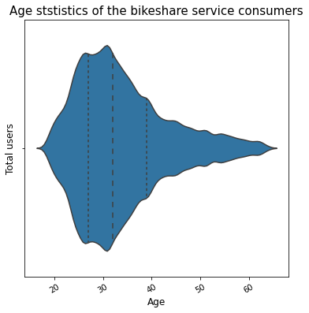

## Ford Bike share service most used start statation

Market St at 10th St is most commonoly used as start station for greater than 3600 service users

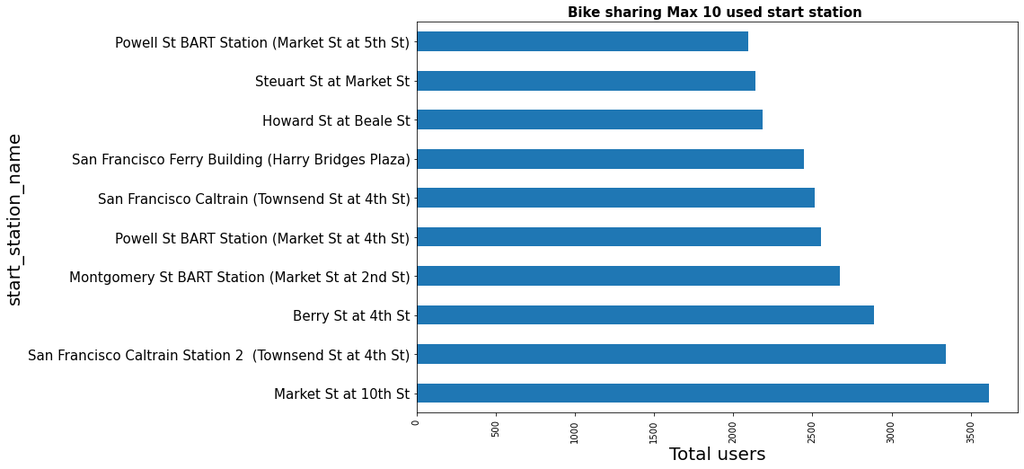

## Trip duration in minutes

Most of the users have a common Trip durattion between 2 and 12 minutes for a ride

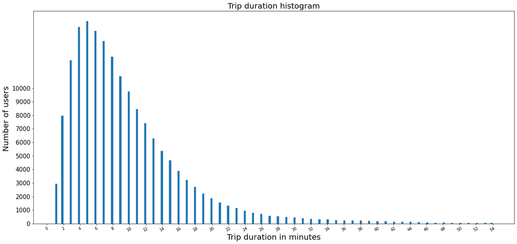

## Rushhour of bikesharing service in day

The rush hours of using Bike sharing service in the day is from 7 to 9 in the morning and from 16-18 after noon

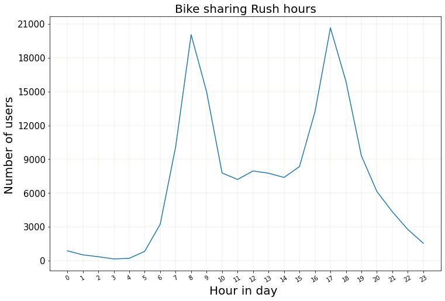

## stations with highest and lowest avaerage users age

5th St at Tylor St station have the highest average users age of 50 years however Haste ST at College Ave station have the lowest average user age of 24.5 years

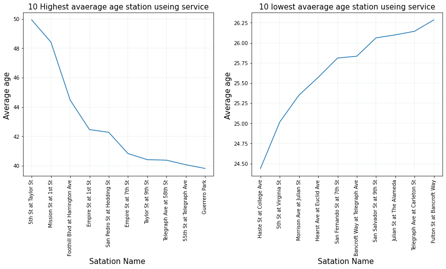

## Users gender vs age and trip duration in minutes

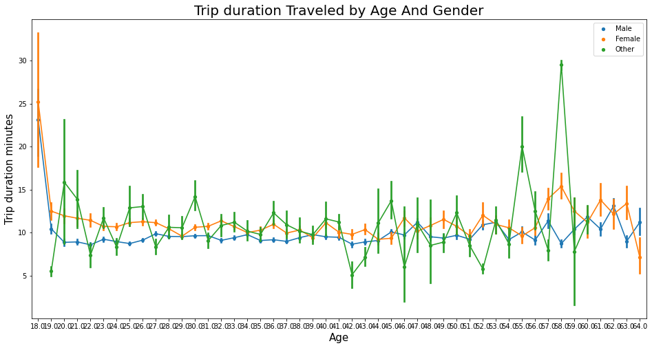

## Gender and usertype services utilization in each hour of the day

1- Male subscriber using the service more frequently than Female and other genders in all day hours 2- Female subscriber use the services more frequently than other gender in all day hours 3- the same roles existed in customers 4- For all genders the rush hours for both subscriber and customers is from 8 to 9 am and 16 to 18 after noon

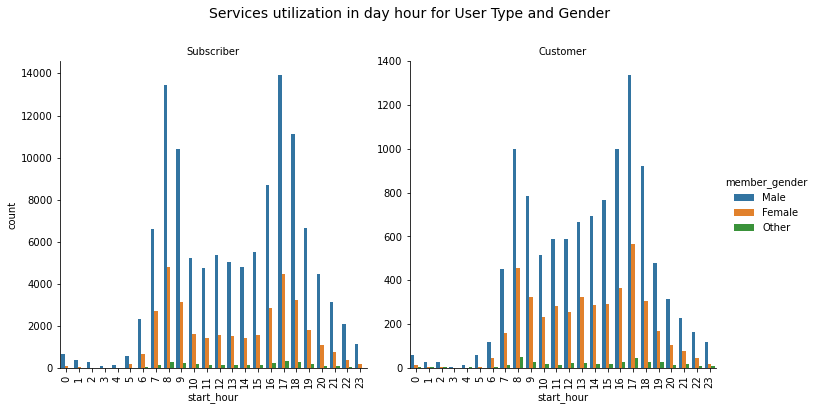